# Testing affect regulation via computational modeling of real-time alcohol choices in daily life: Alcohol Bias

2026-04-06

# 1 About This Report

This report presents results for **Alcohol Bias** (alcbias) across all four focal predictors: stress (binary), stress (state), negative affect (state), and positive affect (state).

For each predictor, the report is organized as follows:

- **Dimensionality reduction:** PCA and UMAP component composition tables, showing which raw variables load most strongly onto each component.
- **GLMM results (raw features):** Summary of results from GLMM model with raw variables.
- **Random forest results (raw features):** Summary of results from random forest model with raw variables.
- **Model comparison:** RMSE comparison table across all methods (GLMM, random forest, decision tree) and feature sets (raw, PCA, UMAP).

# 2 Stress Binary (stress_binary)

## 2.1 Dimensionality Reduction

- **PCA components (80% variance, max 5):** 5
- **UMAP components (matching PCA):** 5

### 2.1.1 PCA Component Composition (top 5 correlated variables)

**PC_1**

| Variable | Correlation |
| --- | --- |
| alc_exp_energeticYes | -0.576 |
| alc_exp_better_moodYes | -0.557 |
| alc_exp_sociableYes | -0.547 |
| alc_exp_buzzYes | -0.502 |
| alc_craving | -0.487 |

**PC_2**

| Variable | Correlation |
| --- | --- |
| alc_exp_injuryYes | -0.596 |
| alc_exp_be_rudeYes | -0.594 |
| alc_exp_embarrassedYes | -0.579 |
| alc_exp_nauseous_vomitYes | -0.491 |
| alc_exp_hangoverYes | -0.468 |

**PC_3**

| Variable | Correlation |
| --- | --- |
| locationschool_work | 0.591 |
| alc_today | -0.578 |
| alc_cuenone | 0.568 |
| time_of_dayevening | -0.476 |
| locationhome | -0.458 |

**PC_4**

| Variable | Correlation |
| --- | --- |
| soft_yday | 0.699 |
| soft_today | 0.650 |
| soft_intend | 0.634 |
| soft_craving | 0.489 |
| alc_exp_embarrassedYes | -0.388 |

**PC_5**

| Variable | Correlation |
| --- | --- |
| locationhome | -0.632 |
| social_context_aloneYes | -0.560 |
| social_context_friend_roommateYes | 0.500 |
| social_context_strangerYes | 0.417 |
| locationsomeone_elses_home | 0.372 |

### 2.1.2 UMAP Component Composition (top 5 correlated variables)

**UMAP_1**

| Variable | Correlation |
| --- | --- |
| alc_exp_embarrassedYes | 0.318 |
| alc_exp_be_rudeYes | 0.316 |
| alc_craving | 0.295 |
| alc_intend | 0.222 |
| soft_yday | 0.187 |

**UMAP_2**

| Variable | Correlation |
| --- | --- |
| alc_yday | -0.425 |
| alc_intend | -0.206 |
| alc_mot_enhanceYes | -0.133 |
| soft_yday | 0.115 |
| alc_cuenone | 0.115 |

**UMAP_3**

| Variable | Correlation |
| --- | --- |
| alc_yday | 0.339 |
| alc_today | 0.332 |
| soft_craving | -0.196 |
| thirst_state | -0.162 |
| soft_yday | -0.156 |

**UMAP_4**

| Variable | Correlation |
| --- | --- |
| soft_yday | -0.751 |
| soft_today | -0.650 |
| soft_intend | -0.523 |
| soft_craving | -0.255 |
| alc_mot_enhanceYes | 0.162 |

**UMAP_5**

| Variable | Correlation |
| --- | --- |
| alc_exp_injuryYes | -0.501 |
| alc_exp_nauseous_vomitYes | -0.356 |
| alc_exp_embarrassedYes | -0.352 |
| alc_exp_be_rudeYes | -0.350 |
| alc_exp_energeticYes | -0.207 |

## 2.2 GLMM Results

### 2.2.1 Raw Features

- **Optimal lambda:** 160 (index 5 of 21)
- **CV RMSE:** 1.5703

**Non-zero coefficients** (focal predictor terms highlighted):

| Term | Estimate | Category |
| --- | --- | --- |
| (Intercept) | -1.1901 | Intercept |
| stress_binary | 0.0370 | Focal predictor |
| alc_exp_nauseous_vomitYes | -0.2319 | Covariate main effect |
| alc_cuenone | -0.1430 | Covariate main effect |
| alc_exp_injuryYes | -0.1394 | Covariate main effect |
| alc_exp_relaxedYes | 0.1248 | Covariate main effect |
| alc_craving | 0.1150 | Covariate main effect |
| alc_mot_enhanceYes | 0.1054 | Covariate main effect |
| alc_exp_be_rudeYes | -0.0929 | Covariate main effect |
| alc_exp_buzzYes | 0.0877 | Covariate main effect |
| alc_exp_better_moodYes | 0.0817 | Covariate main effect |
| alc_exp_embarrassedYes | -0.0775 | Covariate main effect |
| alc_exp_hangoverYes | -0.0648 | Covariate main effect |
| social_context_strangerYes | 0.0633 | Covariate main effect |
| locationrestaurant_cafe | 0.0551 | Covariate main effect |
| social_context_romantic_partnerYes | 0.0524 | Covariate main effect |
| time_of_dayevening | 0.0520 | Covariate main effect |
| alc_intend | 0.0500 | Covariate main effect |
| alc_mot_copingYes | 0.0455 | Covariate main effect |
| social_context_friend_roommateYes | 0.0443 | Covariate main effect |
| alc_exp_sociableYes | 0.0437 | Covariate main effect |
| locationother | 0.0434 | Covariate main effect |
| alc_exp_energeticYes | 0.0419 | Covariate main effect |
| alc_today | 0.0391 | Covariate main effect |
| social_context_familyYes | -0.0344 | Covariate main effect |
| social_context_coworker_classmateYes | -0.0331 | Covariate main effect |
| soft_intend | -0.0308 | Covariate main effect |
| soft_craving | -0.0287 | Covariate main effect |
| locationschool_work | -0.0186 | Covariate main effect |
| bored_state | 0.0177 | Covariate main effect |

[output cut: 60 more lines]

- 8 coefficients penalized to zero.*

#### 2.2.1.1 Predicted vs. Observed

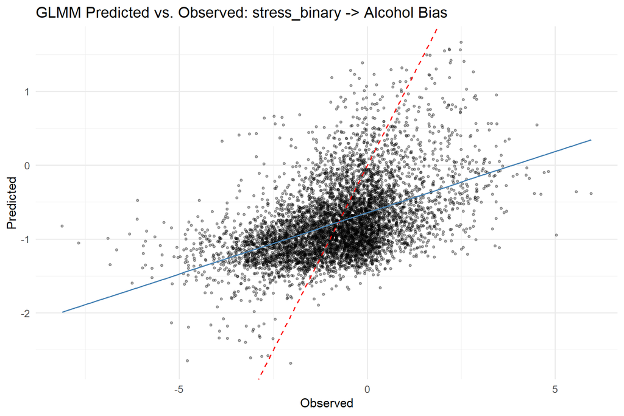

#### 2.2.1.2 Residual Diagnostics

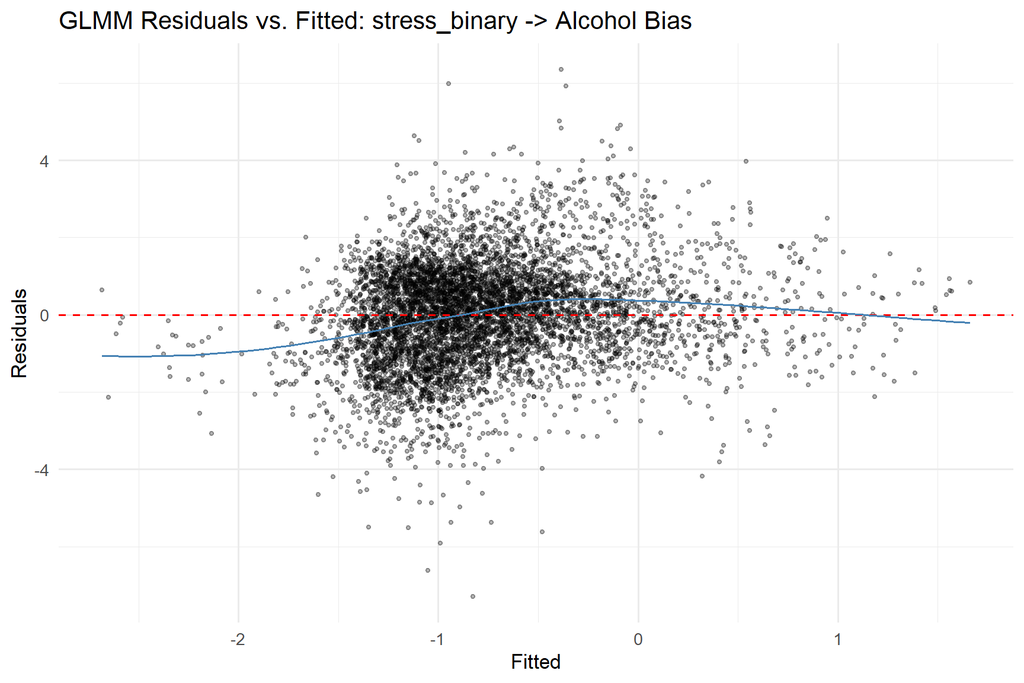

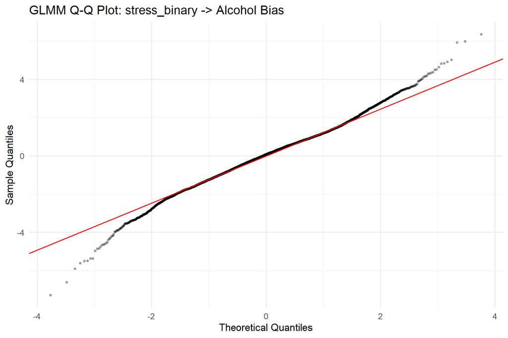

### 2.2.2 PCA Features

- **Optimal lambda:** 180 (index 3 of 21)
- **CV RMSE:** 1.7503

**Non-zero coefficients:**

| Term | Estimate |
| --- | --- |
| (Intercept) | -0.7918 |
| PC_1 | -0.1960 |
| PC_2 | 0.3384 |
| PC_3 | -0.3292 |
| PC_4 | 0.0073 |
| PC_5 | -0.0393 |
| stress_binary | 0.1220 |
| PC_1:stress_binary | -0.0048 |
| PC_2:stress_binary | 0.0204 |
| PC_4:stress_binary | 0.0124 |
| PC_5:stress_binary | -0.0625 |

- 1 coefficients penalized to zero.*

### 2.2.3 UMAP Features

- **Optimal lambda:** 200 (index 1 of 21)
- **CV RMSE:** 1.536

**Non-zero coefficients:**

| Term | Estimate |
| --- | --- |
| (Intercept) | -0.8045 |
| UMAP_1 | 0.1571 |
| UMAP_2 | -0.1000 |
| UMAP_3 | 0.2252 |
| UMAP_4 | 0.2308 |
| UMAP_5 | 0.0560 |
| stress_binary | 0.1718 |
| UMAP_1:stress_binary | 0.0582 |
| UMAP_2:stress_binary | 0.0008 |
| UMAP_3:stress_binary | 0.0251 |
| UMAP_5:stress_binary | 0.1106 |

- 1 coefficients penalized to zero.*

## 2.3 Random Forest Results (Raw)

### 2.3.1 Tuning Summary

- **mtry:** 18
- **min.node.size:** 2
- **sample.fraction:** 0.679
- **CV RMSE:** 1.059

### 2.3.2 Variable Importance (Permutation)

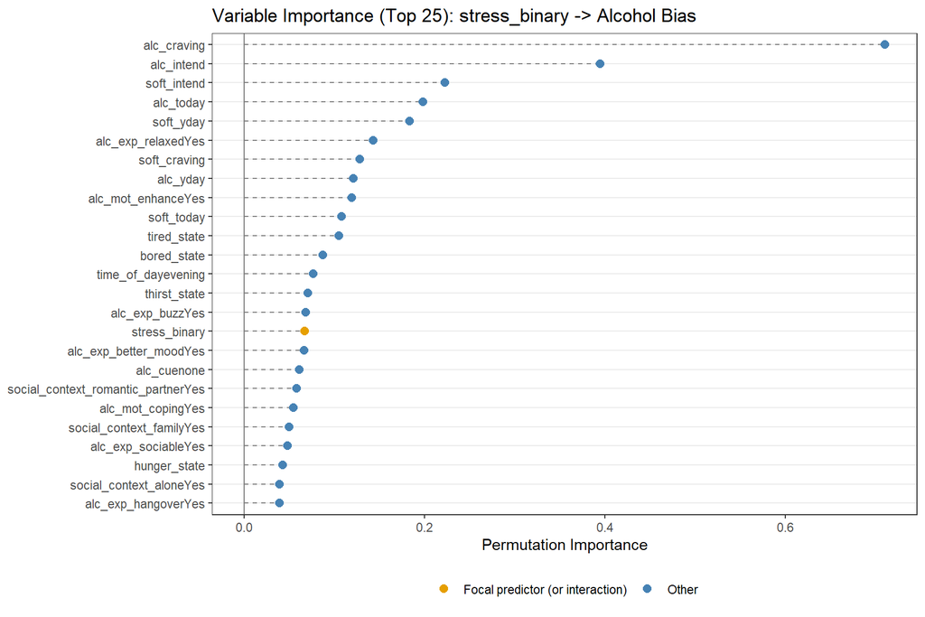

**Full importance ranking:**

| Variable | Importance |
| --- | --- |
| alc_craving | 0.710112 |
| alc_intend | 0.394450 |
| soft_intend | 0.222449 |
| alc_today | 0.197820 |
| soft_yday | 0.182965 |
| alc_exp_relaxedYes | 0.142971 |
| soft_craving | 0.128179 |
| alc_yday | 0.121215 |
| alc_mot_enhanceYes | 0.118929 |
| soft_today | 0.108114 |
| tired_state | 0.105145 |
| bored_state | 0.087435 |
| time_of_dayevening | 0.076587 |
| thirst_state | 0.070240 |
| alc_exp_buzzYes | 0.068130 |
| stress_binary | 0.067139 |
| alc_exp_better_moodYes | 0.066459 |
| alc_cuenone | 0.061021 |
| social_context_romantic_partnerYes | 0.057886 |
| alc_mot_copingYes | 0.054609 |
| social_context_familyYes | 0.050021 |
| alc_exp_sociableYes | 0.048266 |
| hunger_state | 0.042480 |
| social_context_aloneYes | 0.039029 |
| alc_exp_hangoverYes | 0.038835 |
| responsibilityYes | 0.036710 |
| alc_exp_embarrassedYes | 0.024855 |
| alc_exp_nauseous_vomitYes | 0.020446 |
| alc_exp_be_rudeYes | 0.016679 |
| locationhome | 0.016586 |
| alc_exp_energeticYes | 0.013463 |
| alc_mot_socialYes | 0.013039 |
| locationschool_work | 0.010619 |
| alc_exp_injuryYes | 0.004874 |
| locationother | 0.004127 |
| social_context_friend_roommateYes | 0.003687 |
| social_context_coworker_classmateYes | 0.001782 |
| locationsomeone_elses_home | 0.001401 |
| locationoutdoors | 0.001067 |
| alc_cueindirectly_visible | 0.000722 |
| social_context_otherYes | 0.000285 |
| day_of_weekSat | 0.000279 |
| locationrestaurant_cafe | 0.000257 |
| social_context_strangerYes | -0.000128 |
| day_of_weekThu | -0.001683 |
| day_of_weekSun | -0.002088 |
| day_of_weekMon | -0.002422 |
| day_of_weekWed | -0.002428 |
| day_of_weekTue | -0.003081 |

### 2.3.3 Partial Dependence Plots

PDP for the focal predictor and the top 5 most important non-interaction covariates.

#### 2.3.3.1 Focal Predictor: stress_binary

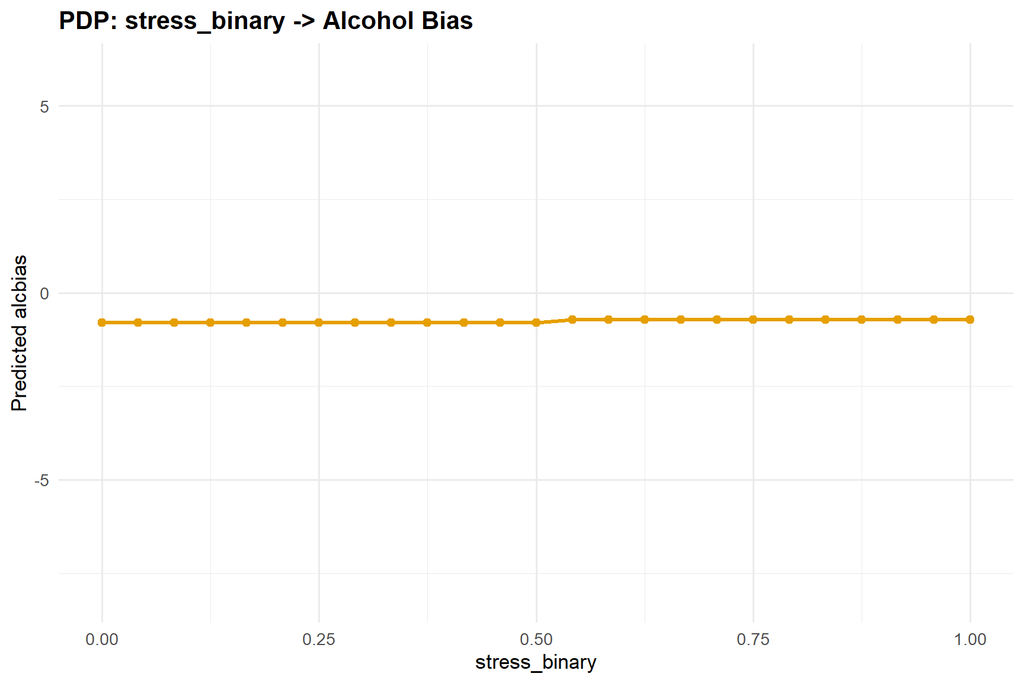

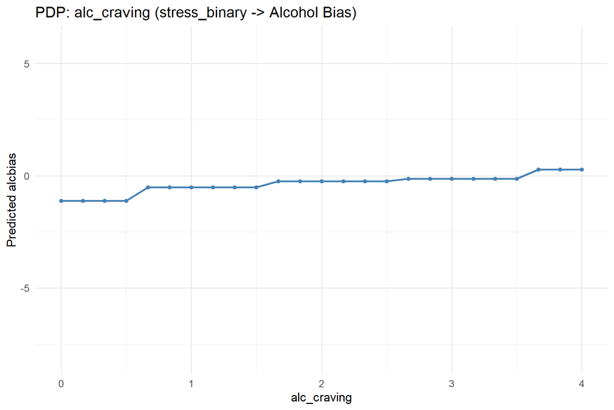

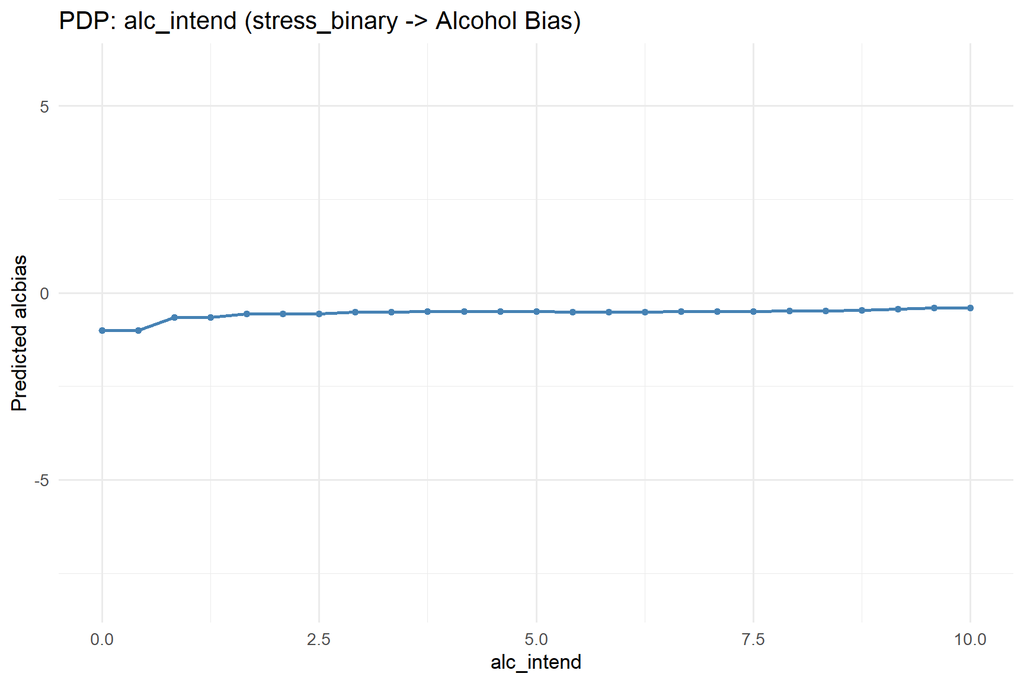

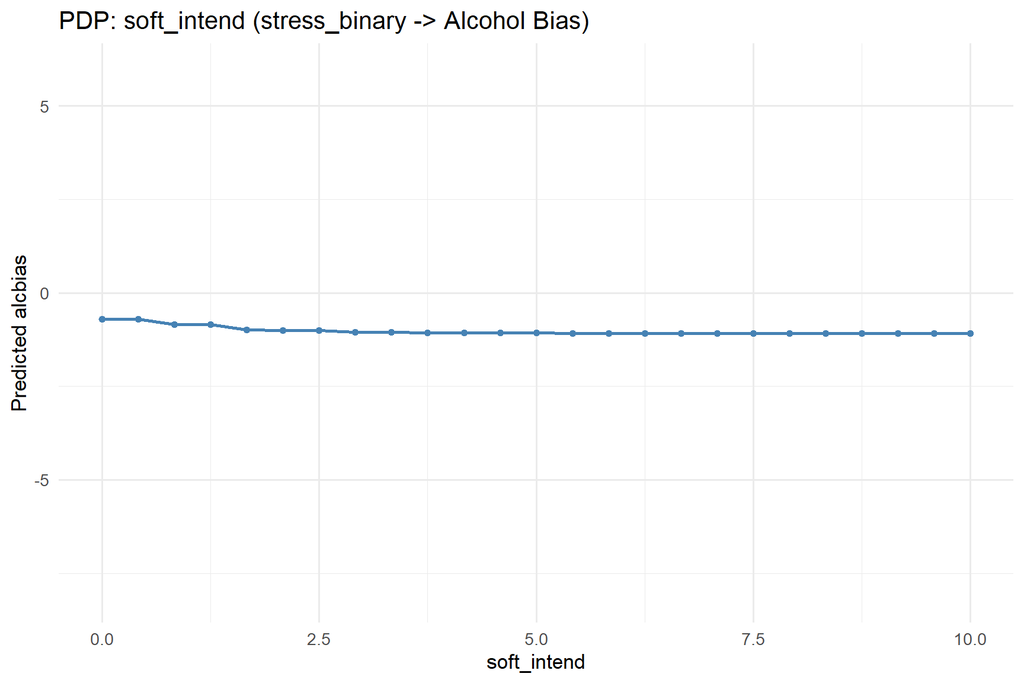

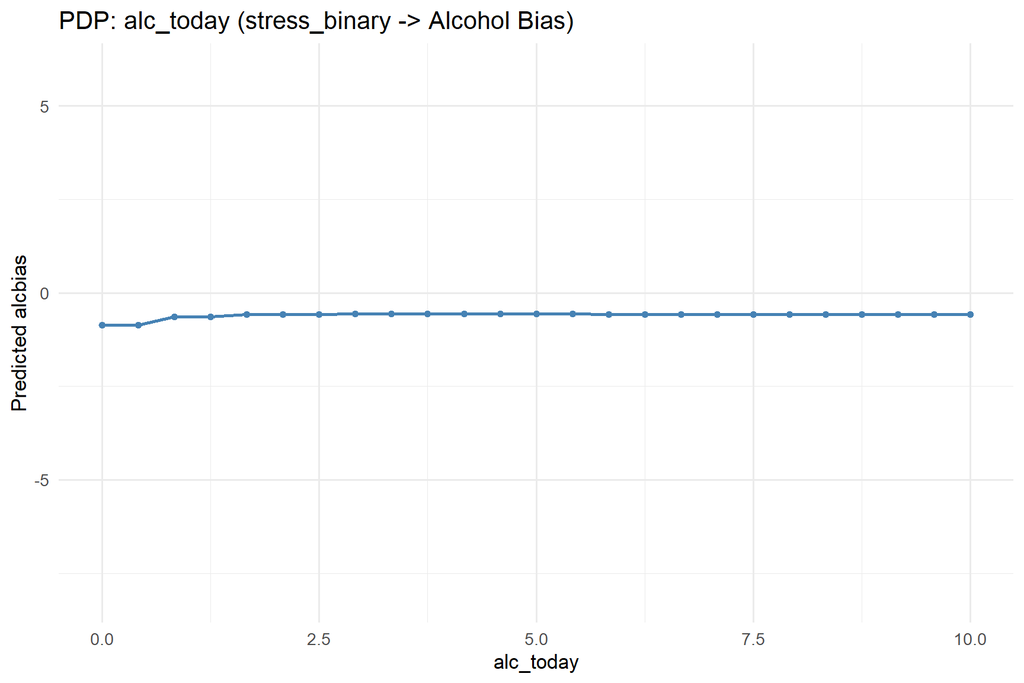

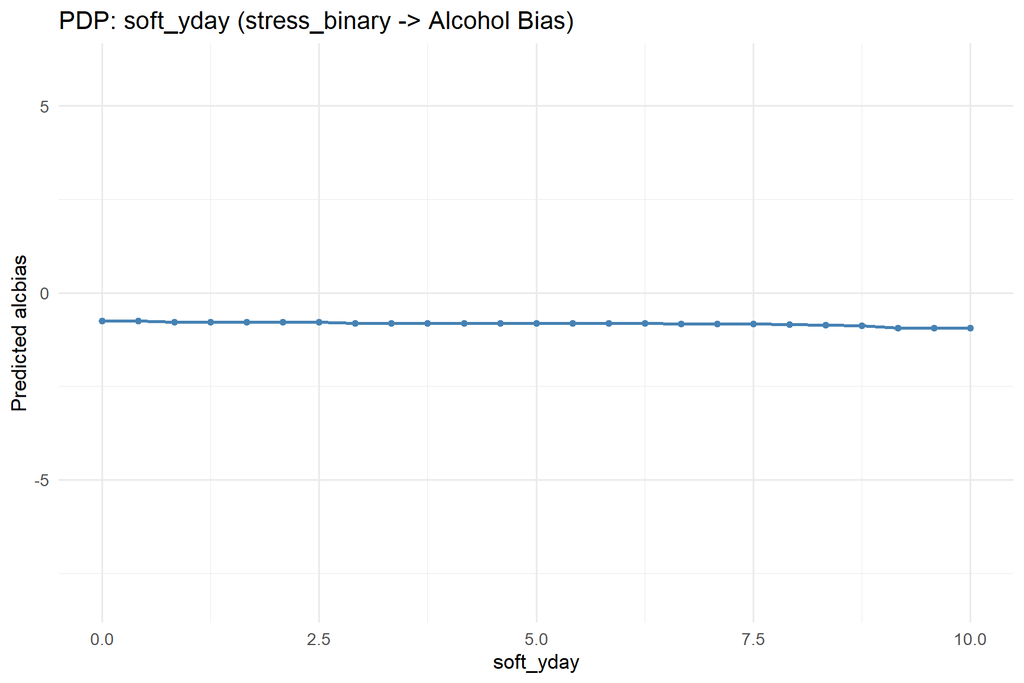

### 2.3.4 Predicted vs. Observed

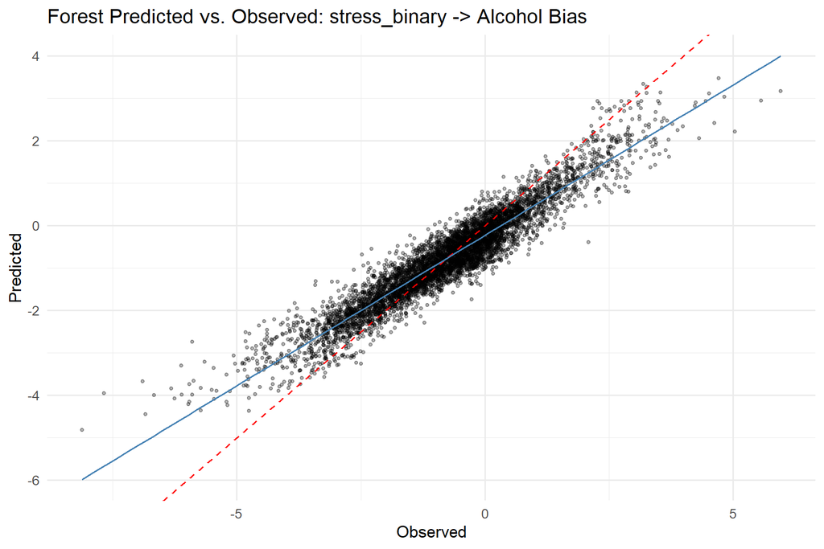

## 2.4 Model Comparison

### 2.4.1 RMSE Comparison (all methods and feature sets)

| Method | Raw | PCA | UMAP |
| --- | --- | --- | --- |
| glmm | 1.5703 | 1.7503 | 1.5360 |
| forest | 1.0590 | 1.2701 | 1.1707 |
| tree | 1.3478 | 1.4203 | 1.4283 |

# 3 Stress State (stress_state)

## 3.1 Dimensionality Reduction

- **PCA components (80% variance, max 5):** 5
- **UMAP components (matching PCA):** 5

### 3.1.1 PCA Component Composition (top 5 correlated variables)

**PC_1**

| Variable | Correlation |
| --- | --- |
| alc_exp_energeticYes | -0.576 |
| alc_exp_better_moodYes | -0.557 |
| alc_exp_sociableYes | -0.547 |
| alc_exp_buzzYes | -0.502 |
| alc_craving | -0.487 |

**PC_2**

| Variable | Correlation |
| --- | --- |
| alc_exp_injuryYes | -0.595 |
| alc_exp_be_rudeYes | -0.593 |
| alc_exp_embarrassedYes | -0.578 |
| alc_exp_nauseous_vomitYes | -0.491 |
| alc_exp_hangoverYes | -0.467 |

**PC_3**

| Variable | Correlation |
| --- | --- |
| locationschool_work | 0.591 |
| alc_today | -0.578 |
| alc_cuenone | 0.569 |
| time_of_dayevening | -0.476 |
| locationhome | -0.459 |

**PC_4**

| Variable | Correlation |
| --- | --- |
| soft_yday | 0.697 |
| soft_today | 0.649 |
| soft_intend | 0.634 |
| soft_craving | 0.489 |
| alc_exp_embarrassedYes | -0.389 |

**PC_5**

| Variable | Correlation |
| --- | --- |
| locationhome | -0.632 |
| social_context_aloneYes | -0.560 |
| social_context_friend_roommateYes | 0.501 |
| social_context_strangerYes | 0.418 |
| locationsomeone_elses_home | 0.372 |

### 3.1.2 UMAP Component Composition (top 5 correlated variables)

**UMAP_1**

| Variable | Correlation |
| --- | --- |
| alc_exp_embarrassedYes | -0.311 |
| alc_exp_be_rudeYes | -0.307 |
| alc_craving | -0.239 |
| alc_intend | -0.187 |
| alc_mot_copingYes | -0.146 |

**UMAP_2**

| Variable | Correlation |
| --- | --- |
| alc_yday | 0.408 |
| alc_intend | 0.176 |
| soft_yday | -0.151 |
| alc_mot_enhanceYes | 0.124 |
| soft_today | -0.113 |

**UMAP_3**

| Variable | Correlation |
| --- | --- |
| alc_today | 0.405 |
| alc_yday | 0.381 |
| alc_intend | 0.194 |
| alc_cuenone | -0.181 |
| responsibilityYes | -0.134 |

**UMAP_4**

| Variable | Correlation |
| --- | --- |
| soft_yday | -0.763 |
| soft_today | -0.661 |
| soft_intend | -0.534 |
| soft_craving | -0.272 |
| alc_exp_be_rudeYes | -0.153 |

**UMAP_5**

| Variable | Correlation |
| --- | --- |
| alc_exp_injuryYes | -0.517 |
| alc_exp_embarrassedYes | -0.391 |
| alc_exp_be_rudeYes | -0.389 |
| alc_exp_nauseous_vomitYes | -0.361 |
| alc_exp_energeticYes | -0.227 |

## 3.2 GLMM Results

### 3.2.1 Raw Features

- **Optimal lambda:** 200 (index 1 of 21)
- **CV RMSE:** 1.5635

**Non-zero coefficients** (focal predictor terms highlighted):

| Term | Estimate | Category |
| --- | --- | --- |
| (Intercept) | -1.2391 | Intercept |
| stress_state | 0.0141 | Focal predictor |
| alc_exp_nauseous_vomitYes | -0.2141 | Covariate main effect |
| alc_cuenone | -0.1326 | Covariate main effect |
| alc_exp_injuryYes | -0.1277 | Covariate main effect |
| alc_exp_relaxedYes | 0.1153 | Covariate main effect |
| alc_craving | 0.1073 | Covariate main effect |
| alc_mot_enhanceYes | 0.0978 | Covariate main effect |
| alc_exp_be_rudeYes | -0.0848 | Covariate main effect |
| alc_exp_buzzYes | 0.0809 | Covariate main effect |
| alc_exp_better_moodYes | 0.0737 | Covariate main effect |
| alc_exp_embarrassedYes | -0.0702 | Covariate main effect |
| alc_exp_hangoverYes | -0.0578 | Covariate main effect |
| social_context_strangerYes | 0.0530 | Covariate main effect |
| time_of_dayevening | 0.0476 | Covariate main effect |
| alc_intend | 0.0459 | Covariate main effect |
| social_context_romantic_partnerYes | 0.0429 | Covariate main effect |
| alc_exp_sociableYes | 0.0404 | Covariate main effect |
| social_context_friend_roommateYes | 0.0391 | Covariate main effect |
| locationrestaurant_cafe | 0.0368 | Covariate main effect |
| alc_today | 0.0358 | Covariate main effect |
| alc_mot_copingYes | 0.0355 | Covariate main effect |
| alc_exp_energeticYes | 0.0334 | Covariate main effect |
| locationother | 0.0323 | Covariate main effect |
| soft_intend | -0.0285 | Covariate main effect |
| social_context_familyYes | -0.0280 | Covariate main effect |
| soft_craving | -0.0259 | Covariate main effect |
| social_context_coworker_classmateYes | -0.0257 | Covariate main effect |
| alc_yday | 0.0148 | Covariate main effect |
| bored_state | 0.0123 | Covariate main effect |

[output cut: 59 more lines]

- 9 coefficients penalized to zero.*

#### 3.2.1.1 Predicted vs. Observed

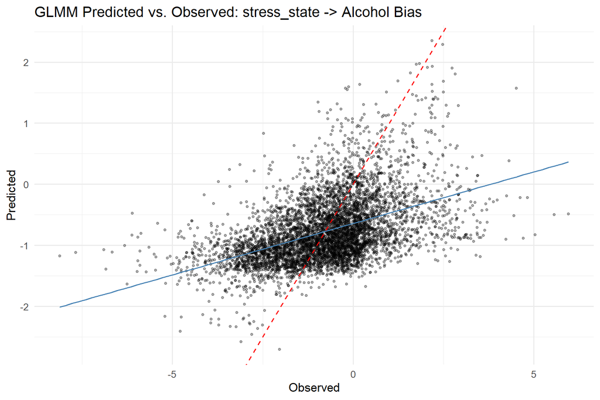

#### 3.2.1.2 Residual Diagnostics

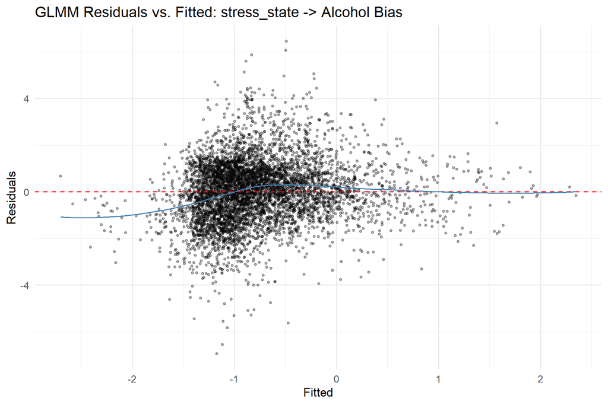

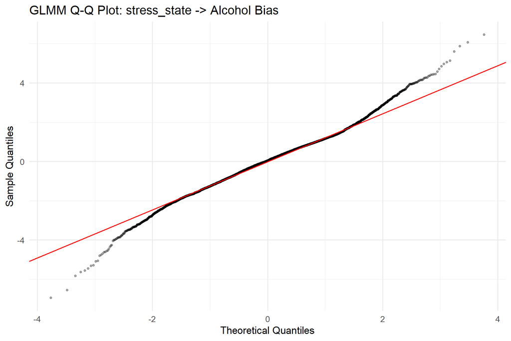

### 3.2.2 PCA Features

- **Optimal lambda:** 170 (index 4 of 21)
- **CV RMSE:** 1.7724

**Non-zero coefficients:**

| Term | Estimate |
| --- | --- |
| (Intercept) | -0.8309 |
| PC_1 | -0.1722 |
| PC_2 | 0.3599 |
| PC_3 | -0.3281 |
| PC_4 | 0.0049 |
| PC_5 | -0.0218 |
| stress_state | 0.0806 |
| PC_2:stress_state | 0.0086 |
| PC_3:stress_state | -0.0147 |
| PC_5:stress_state | -0.0260 |

- 2 coefficients penalized to zero.*

### 3.2.3 UMAP Features

- **Optimal lambda:** 200 (index 1 of 21)
- **CV RMSE:** 1.5831

**Non-zero coefficients:**

| Term | Estimate |
| --- | --- |
| (Intercept) | -0.9047 |
| UMAP_1 | -0.0393 |
| UMAP_2 | 0.0841 |
| UMAP_3 | 0.1546 |
| UMAP_4 | 0.1694 |
| UMAP_5 | 0.0065 |
| stress_state | 0.1459 |
| UMAP_2:stress_state | 0.0452 |
| UMAP_3:stress_state | 0.0644 |
| UMAP_4:stress_state | 0.0548 |
| UMAP_5:stress_state | 0.0291 |

- 1 coefficients penalized to zero.*

## 3.3 Random Forest Results (Raw)

### 3.3.1 Tuning Summary

- **mtry:** 20
- **min.node.size:** 2
- **sample.fraction:** 0.691
- **CV RMSE:** 1.0496

### 3.3.2 Variable Importance (Permutation)

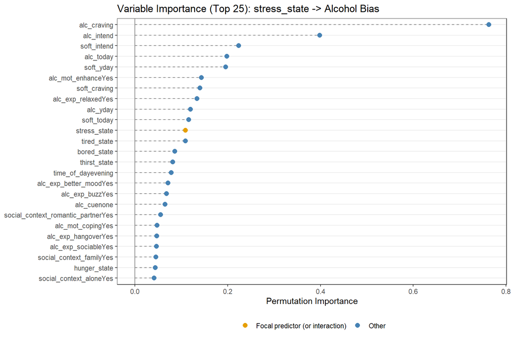

**Full importance ranking:**

| Variable | Importance |
| --- | --- |
| alc_craving | 0.762991 |
| alc_intend | 0.398050 |
| soft_intend | 0.223968 |
| alc_today | 0.197950 |
| soft_yday | 0.195930 |
| alc_mot_enhanceYes | 0.143131 |
| soft_craving | 0.140131 |
| alc_exp_relaxedYes | 0.133693 |
| alc_yday | 0.119873 |
| soft_today | 0.116258 |
| stress_state | 0.109249 |
| tired_state | 0.108652 |
| bored_state | 0.085975 |
| thirst_state | 0.081560 |
| time_of_dayevening | 0.078482 |
| alc_exp_better_moodYes | 0.071275 |
| alc_exp_buzzYes | 0.068429 |
| alc_cuenone | 0.064859 |
| social_context_romantic_partnerYes | 0.055118 |
| alc_mot_copingYes | 0.047597 |
| alc_exp_hangoverYes | 0.046850 |
| alc_exp_sociableYes | 0.046634 |
| social_context_familyYes | 0.045013 |
| hunger_state | 0.043918 |
| social_context_aloneYes | 0.041570 |
| responsibilityYes | 0.041412 |
| alc_exp_embarrassedYes | 0.027015 |
| alc_exp_nauseous_vomitYes | 0.018710 |
| locationhome | 0.018229 |
| alc_exp_be_rudeYes | 0.017273 |
| alc_exp_energeticYes | 0.015397 |
| alc_mot_socialYes | 0.012316 |
| locationschool_work | 0.009670 |
| alc_exp_injuryYes | 0.005505 |
| locationother | 0.005468 |
| social_context_friend_roommateYes | 0.002138 |
| social_context_coworker_classmateYes | 0.001630 |
| locationsomeone_elses_home | 0.001038 |
| alc_cueindirectly_visible | 0.000936 |
| day_of_weekSat | 0.000889 |
| social_context_strangerYes | 0.000255 |
| social_context_otherYes | 0.000204 |
| locationoutdoors | 0.000194 |
| locationrestaurant_cafe | 0.000007 |
| day_of_weekWed | -0.000527 |
| day_of_weekSun | -0.001040 |
| day_of_weekTue | -0.002101 |
| day_of_weekThu | -0.002646 |
| day_of_weekMon | -0.003590 |

### 3.3.3 Partial Dependence Plots

PDP for the focal predictor and the top 5 most important non-interaction covariates.

#### 3.3.3.1 Focal Predictor: stress_state

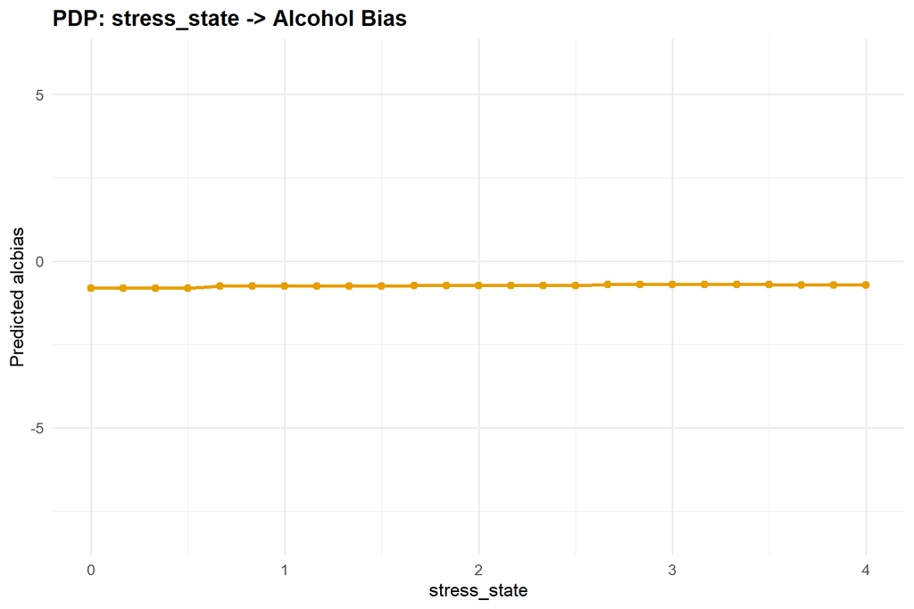

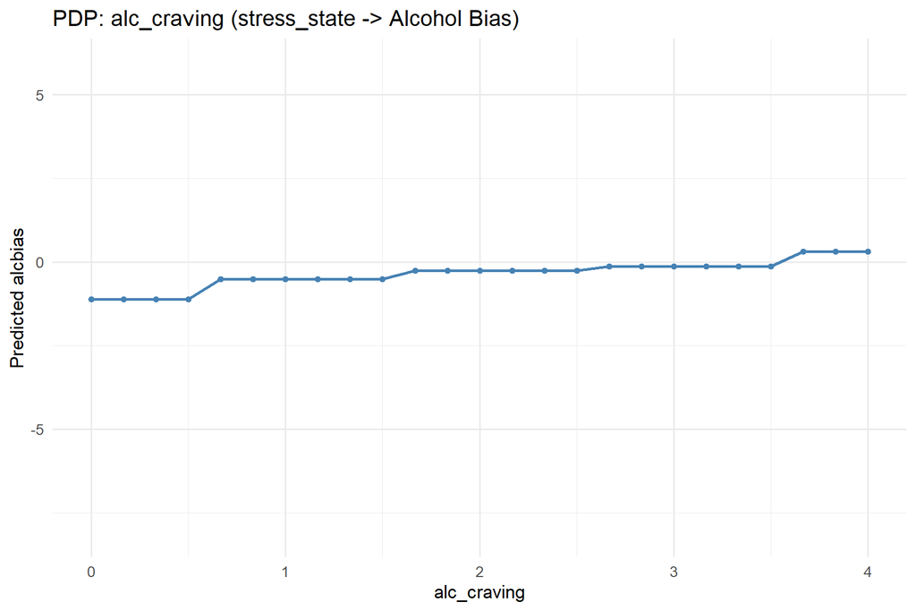

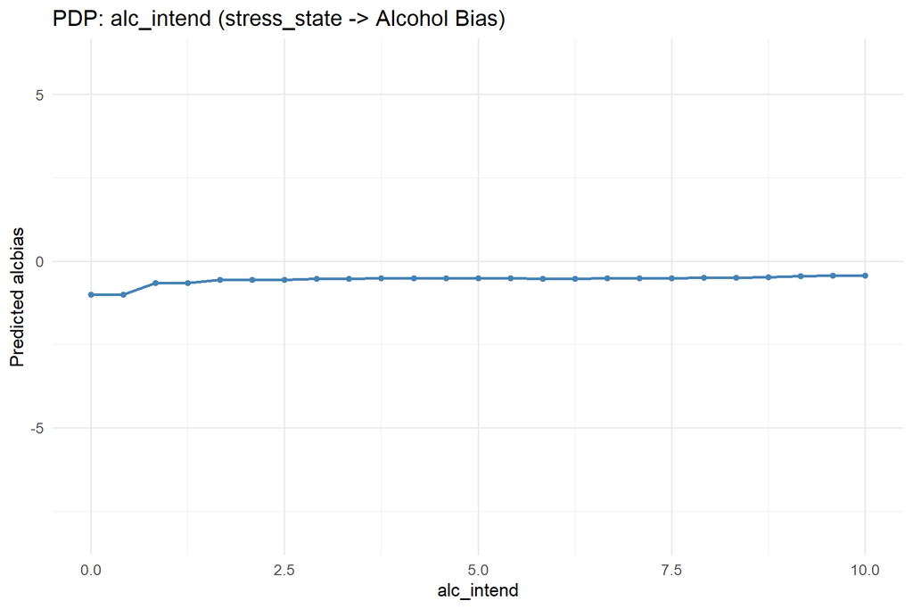

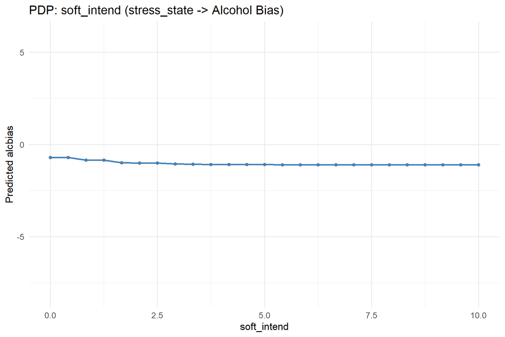

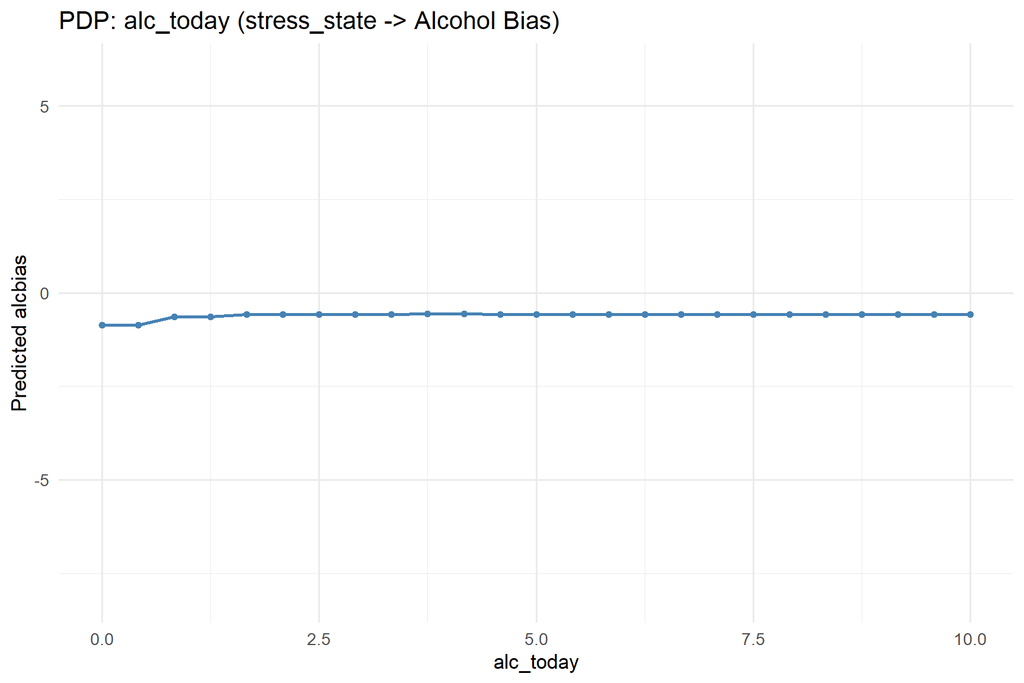

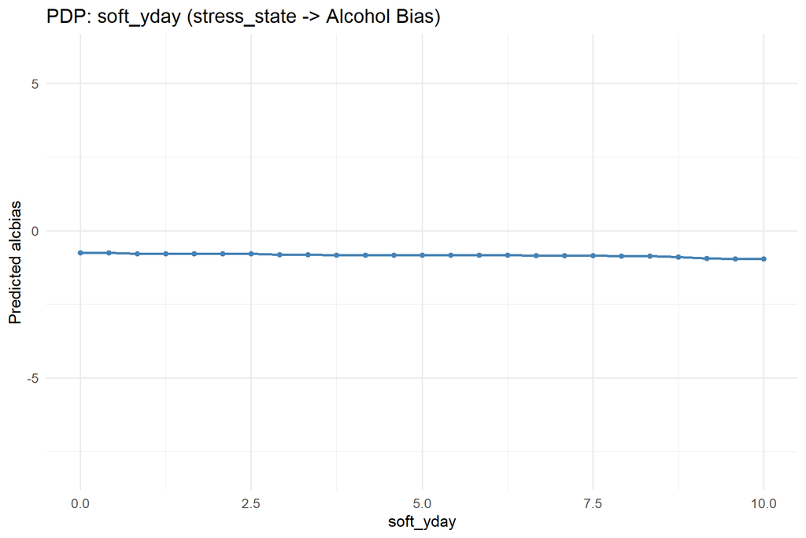

### 3.3.4 Predicted vs. Observed

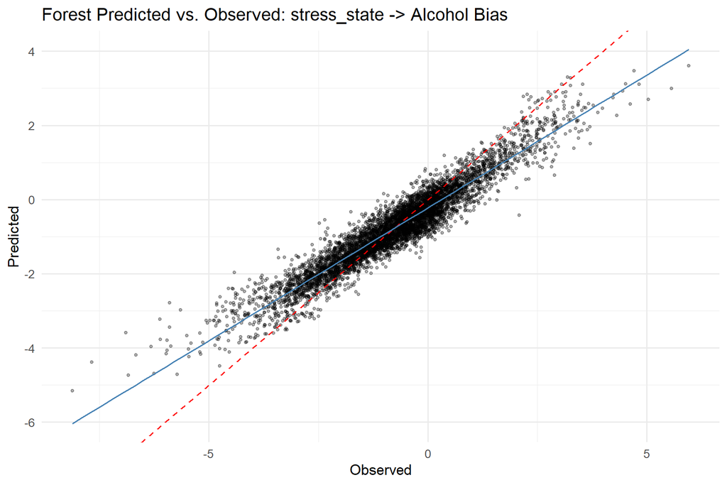

## 3.4 Model Comparison

### 3.4.1 RMSE Comparison (all methods and feature sets)

| Method | Raw | PCA | UMAP |
| --- | --- | --- | --- |
| glmm | 1.5635 | 1.7724 | 1.5831 |
| forest | 1.0496 | 1.2639 | 1.1689 |
| tree | 1.3494 | 1.4228 | 1.4234 |

# 4 Negative Affect State (NA_state)

## 4.1 Dimensionality Reduction

- **PCA components (80% variance, max 5):** 5
- **UMAP components (matching PCA):** 5

### 4.1.1 PCA Component Composition (top 5 correlated variables)

**PC_1**

| Variable | Correlation |
| --- | --- |
| alc_exp_energeticYes | -0.576 |
| alc_exp_better_moodYes | -0.557 |
| alc_exp_sociableYes | -0.547 |
| alc_exp_buzzYes | -0.502 |
| alc_craving | -0.487 |

**PC_2**

| Variable | Correlation |
| --- | --- |
| alc_exp_injuryYes | -0.596 |
| alc_exp_be_rudeYes | -0.594 |
| alc_exp_embarrassedYes | -0.579 |
| alc_exp_nauseous_vomitYes | -0.491 |
| alc_exp_hangoverYes | -0.468 |

**PC_3**

| Variable | Correlation |
| --- | --- |
| locationschool_work | 0.591 |
| alc_today | -0.578 |
| alc_cuenone | 0.569 |
| time_of_dayevening | -0.476 |
| locationhome | -0.457 |

**PC_4**

| Variable | Correlation |
| --- | --- |
| soft_yday | 0.700 |
| soft_today | 0.650 |
| soft_intend | 0.635 |
| soft_craving | 0.488 |
| alc_exp_embarrassedYes | -0.388 |

**PC_5**

| Variable | Correlation |
| --- | --- |
| locationhome | -0.634 |
| social_context_aloneYes | -0.558 |
| social_context_friend_roommateYes | 0.499 |
| social_context_strangerYes | 0.418 |
| locationsomeone_elses_home | 0.371 |

### 4.1.2 UMAP Component Composition (top 5 correlated variables)

**UMAP_1**

| Variable | Correlation |
| --- | --- |
| alc_exp_embarrassedYes | -0.293 |
| alc_exp_be_rudeYes | -0.288 |
| alc_craving | -0.238 |
| alc_intend | -0.205 |
| alc_yday | -0.175 |

**UMAP_2**

| Variable | Correlation |
| --- | --- |
| alc_yday | 0.359 |
| alc_exp_embarrassedYes | -0.143 |
| alc_exp_be_rudeYes | -0.140 |
| alc_intend | 0.130 |
| soft_yday | -0.124 |

**UMAP_3**

| Variable | Correlation |
| --- | --- |
| alc_yday | -0.434 |
| alc_today | -0.392 |
| alc_intend | -0.184 |
| alc_cuenone | 0.176 |
| soft_craving | 0.166 |

**UMAP_4**

| Variable | Correlation |
| --- | --- |
| soft_yday | 0.764 |
| soft_today | 0.665 |
| soft_intend | 0.548 |
| soft_craving | 0.274 |
| alc_today | 0.194 |

**UMAP_5**

| Variable | Correlation |
| --- | --- |
| alc_exp_injuryYes | 0.507 |
| alc_exp_embarrassedYes | 0.379 |
| alc_exp_be_rudeYes | 0.377 |
| alc_exp_nauseous_vomitYes | 0.354 |
| alc_exp_energeticYes | 0.233 |

## 4.2 GLMM Results

### 4.2.1 Raw Features

- **Optimal lambda:** 170 (index 4 of 21)
- **CV RMSE:** 1.5736

**Non-zero coefficients** (focal predictor terms highlighted):

| Term | Estimate | Category |
| --- | --- | --- |
| (Intercept) | -1.2725 | Intercept |
| alc_exp_nauseous_vomitYes | -0.3932 | Covariate main effect |
| alc_craving | 0.2403 | Covariate main effect |
| alc_cuenone | -0.2204 | Covariate main effect |
| alc_exp_relaxedYes | 0.1931 | Covariate main effect |
| alc_mot_enhanceYes | 0.1530 | Covariate main effect |
| alc_exp_buzzYes | 0.1202 | Covariate main effect |
| alc_exp_be_rudeYes | -0.1052 | Covariate main effect |
| social_context_romantic_partnerYes | 0.1019 | Covariate main effect |
| alc_exp_injuryYes | -0.0988 | Covariate main effect |
| time_of_dayevening | 0.0985 | Covariate main effect |
| locationother | 0.0943 | Covariate main effect |
| social_context_familyYes | -0.0915 | Covariate main effect |
| alc_exp_hangoverYes | -0.0900 | Covariate main effect |
| alc_exp_embarrassedYes | -0.0871 | Covariate main effect |
| social_context_strangerYes | 0.0847 | Covariate main effect |
| alc_intend | 0.0800 | Covariate main effect |
| soft_intend | -0.0664 | Covariate main effect |
| social_context_coworker_classmateYes | -0.0593 | Covariate main effect |
| alc_today | 0.0586 | Covariate main effect |
| alc_exp_better_moodYes | 0.0527 | Covariate main effect |
| soft_craving | -0.0442 | Covariate main effect |
| bored_state | 0.0321 | Covariate main effect |
| alc_exp_sociableYes | 0.0250 | Covariate main effect |
| locationrestaurant_cafe | 0.0213 | Covariate main effect |
| locationhome | -0.0196 | Covariate main effect |
| soft_yday | -0.0179 | Covariate main effect |
| alc_yday | 0.0153 | Covariate main effect |
| thirst_state | 0.0108 | Covariate main effect |
| responsibilityYes | 0.0053 | Covariate main effect |

[output cut: 59 more lines]

- 9 coefficients penalized to zero.*

#### 4.2.1.1 Predicted vs. Observed

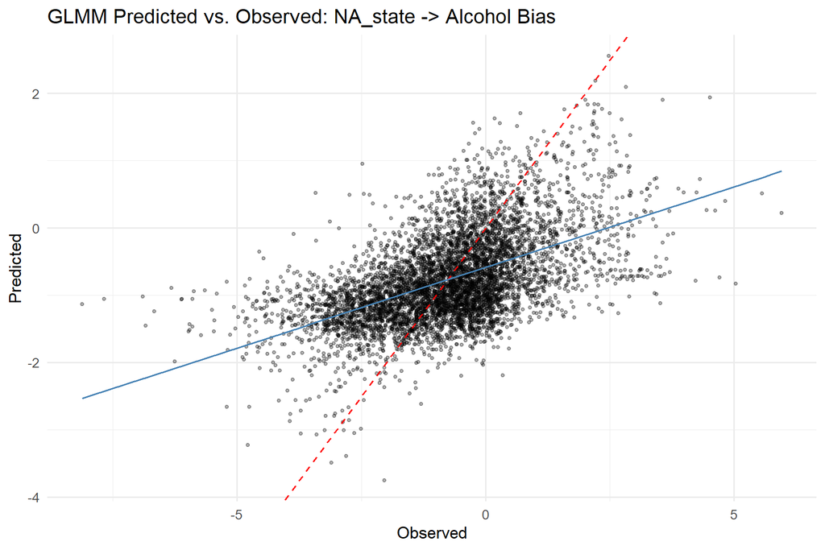

#### 4.2.1.2 Residual Diagnostics

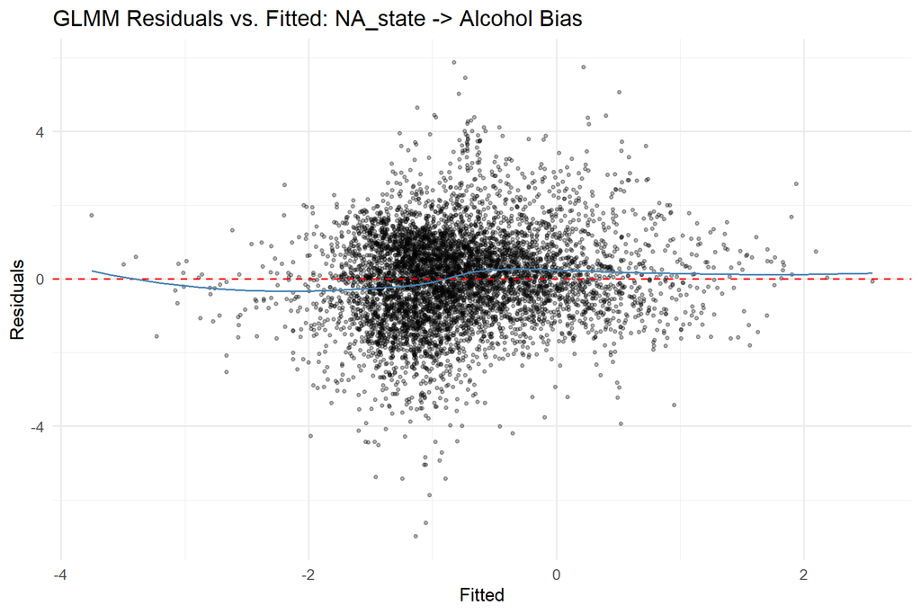

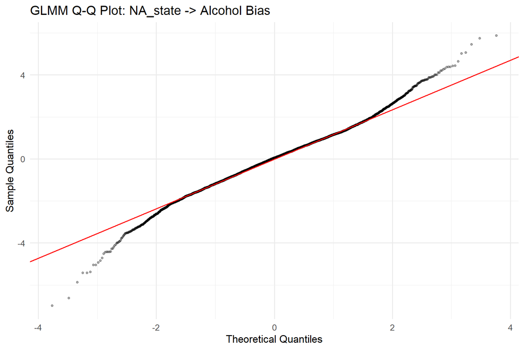

### 4.2.2 PCA Features

- **Optimal lambda:** 200 (index 1 of 21)
- **CV RMSE:** 1.7565

**Non-zero coefficients:**

| Term | Estimate |
| --- | --- |
| (Intercept) | -0.8453 |
| PC_1 | -0.1879 |
| PC_2 | 0.3929 |
| PC_3 | -0.3180 |
| PC_4 | 0.0076 |
| PC_5 | -0.0459 |
| NA_state | 0.0822 |
| PC_1:NA_state | 0.0010 |
| PC_2:NA_state | -0.0008 |
| PC_3:NA_state | -0.0214 |
| PC_5:NA_state | -0.0130 |

- 1 coefficients penalized to zero.*

### 4.2.3 UMAP Features

- **Optimal lambda:** 130 (index 8 of 21)
- **CV RMSE:** 1.5822

**Non-zero coefficients:**

| Term | Estimate |
| --- | --- |
| (Intercept) | -0.8111 |
| UMAP_1 | -0.1852 |
| UMAP_2 | 0.0116 |
| UMAP_3 | -0.2245 |
| UMAP_4 | -0.1905 |
| NA_state | 0.0625 |
| UMAP_1:NA_state | 0.0034 |
| UMAP_2:NA_state | 0.0131 |
| UMAP_3:NA_state | -0.0245 |
| UMAP_4:NA_state | -0.0129 |
| UMAP_5:NA_state | -0.0019 |

- 1 coefficients penalized to zero.*

## 4.3 Random Forest Results (Raw)

### 4.3.1 Tuning Summary

- **mtry:** 18
- **min.node.size:** 2
- **sample.fraction:** 0.63
- **CV RMSE:** 1.0515

### 4.3.2 Variable Importance (Permutation)

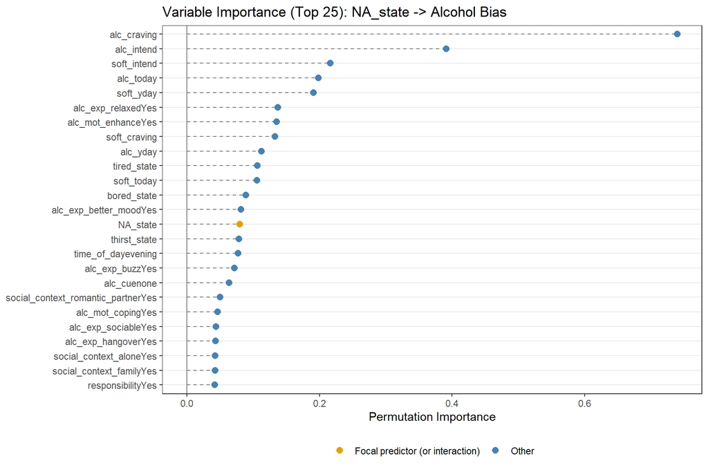

**Full importance ranking:**

| Variable | Importance |
| --- | --- |
| alc_craving | 0.740066 |
| alc_intend | 0.391581 |
| soft_intend | 0.216418 |
| alc_today | 0.198408 |
| soft_yday | 0.191241 |
| alc_exp_relaxedYes | 0.137004 |
| alc_mot_enhanceYes | 0.135211 |
| soft_craving | 0.133111 |
| alc_yday | 0.112738 |
| tired_state | 0.105994 |
| soft_today | 0.105668 |
| bored_state | 0.088851 |
| alc_exp_better_moodYes | 0.081587 |
| NA_state | 0.079692 |
| thirst_state | 0.078570 |
| time_of_dayevening | 0.077406 |
| alc_exp_buzzYes | 0.071554 |
| alc_cuenone | 0.063466 |
| social_context_romantic_partnerYes | 0.050083 |
| alc_mot_copingYes | 0.046293 |
| alc_exp_sociableYes | 0.044088 |
| alc_exp_hangoverYes | 0.043140 |
| social_context_aloneYes | 0.042791 |
| social_context_familyYes | 0.042539 |
| responsibilityYes | 0.041781 |
| hunger_state | 0.039548 |
| alc_exp_embarrassedYes | 0.025776 |
| alc_exp_nauseous_vomitYes | 0.020393 |
| alc_exp_be_rudeYes | 0.017664 |
| locationhome | 0.016381 |
| alc_exp_energeticYes | 0.014801 |
| alc_mot_socialYes | 0.013753 |
| locationschool_work | 0.010849 |
| alc_exp_injuryYes | 0.004867 |
| locationother | 0.003829 |
| social_context_friend_roommateYes | 0.003431 |
| day_of_weekSat | 0.003073 |
| social_context_coworker_classmateYes | 0.001265 |
| alc_cueindirectly_visible | 0.000979 |
| social_context_strangerYes | 0.000796 |
| locationsomeone_elses_home | 0.000762 |
| locationoutdoors | 0.000607 |
| social_context_otherYes | 0.000293 |
| locationrestaurant_cafe | 0.000218 |
| day_of_weekSun | -0.000893 |
| day_of_weekMon | -0.001723 |
| day_of_weekWed | -0.001836 |
| day_of_weekThu | -0.002735 |
| day_of_weekTue | -0.002897 |

### 4.3.3 Partial Dependence Plots

PDP for the focal predictor and the top 5 most important non-interaction covariates.

#### 4.3.3.1 Focal Predictor: NA_state

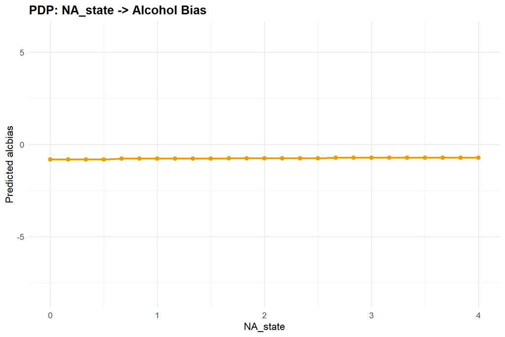

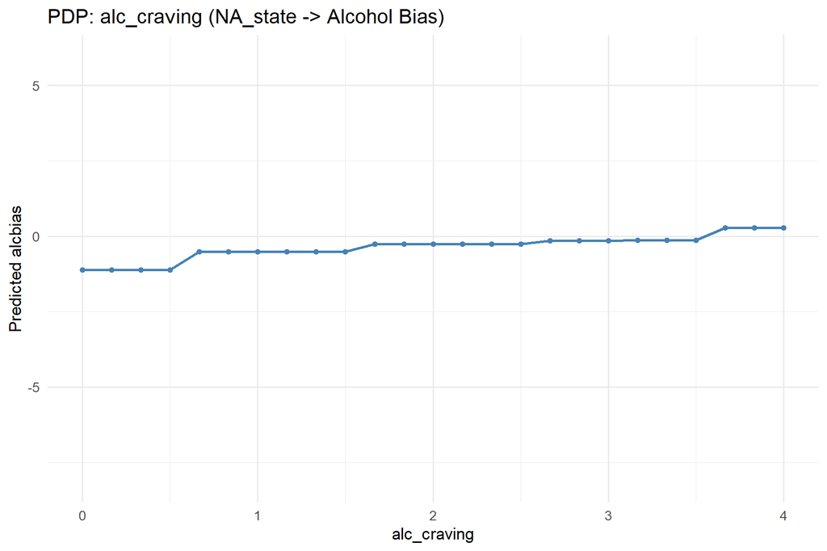

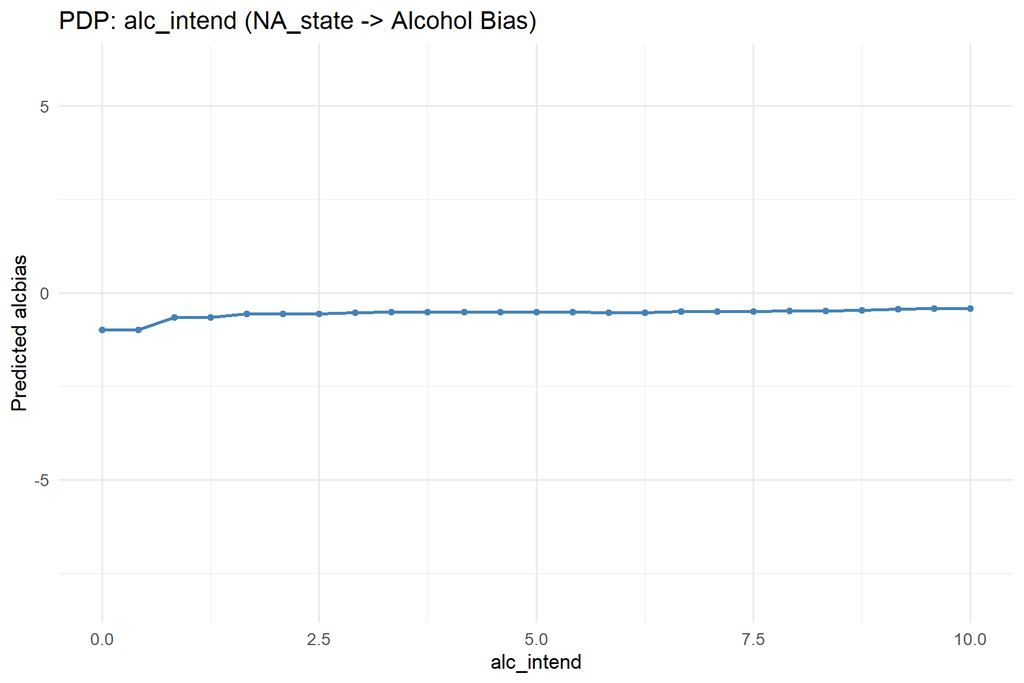

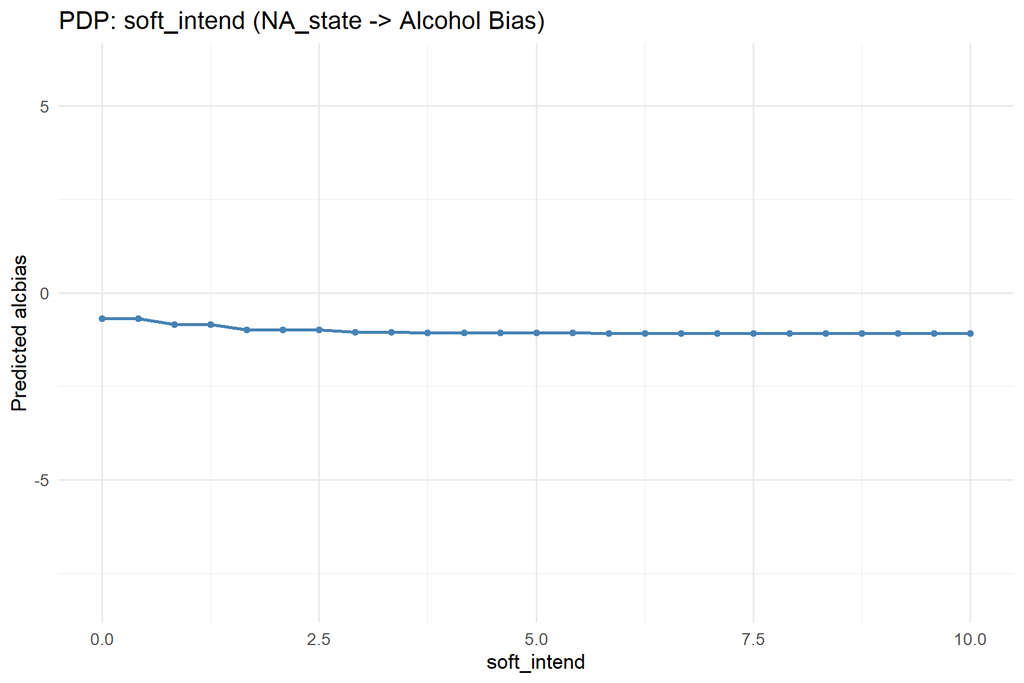

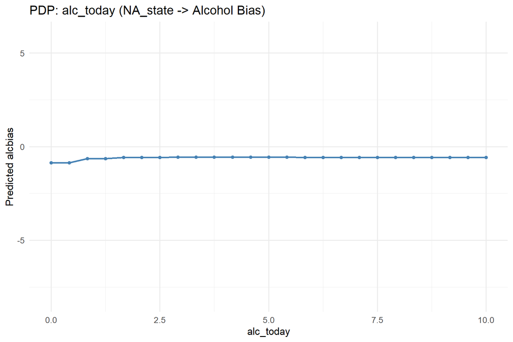

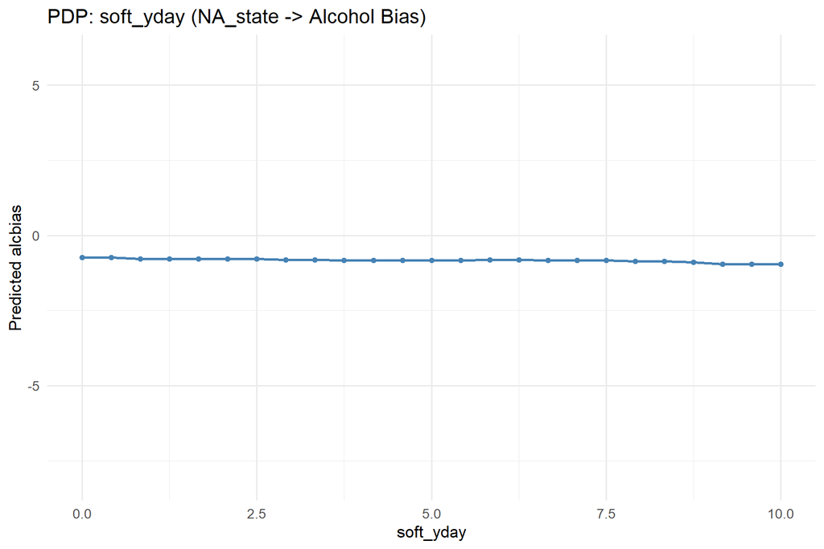